# Exploring Data

Damian Thomas

2016-09-16

## Welcome & Setup

1. Log in to network
2. Update course materials from github
   - https://github.com/wampeh1/ECOG_314
3. Open lecture file in RStudio
   - Lecture3.Rmd

## Midterm Project

- Instructions

## Homework

- Feedback
- Next Homework

## Quick Assessment

What statistical software have students used in the past?

- Stata
- SAS
- Excel
- SPSS
- Matlab
- Other

Compare to the [broader trends](http://r4stats.com/articles/popularity/)

## Refereshers

### Rstudio Interface

Four panels and a menu: each part of the interface serves a purpose

- **Inputs** to R from user
  - Console: interactive R prompt
  - Text Editor: view, create, and change contents of text files
- **Outputs** from R
  - Console: interactive R prompt
  - Environment: current workspace, previous commands
  - Viewer: View plots, help documentation, etc.
- **Options** change the interface or R session
  - Menu: many options and functions available
  - Environment: quick access to workspace

### Managing Your Rstudio Session

- **Save workspace**: write objects in memory to a file
  - go to the Environment tab >> click on the blue disk icon
  - go the Session menu >> select Save Workspace As
  - use the save() function
  - Why? *Keep your work without having to recompute*
- **Clear workspace**: remove objects from memory
  - go to the Environment tab >> click on the yellow broom icon
  - go the Session menu >> select Clear Workspace
  - use the ls() and rm() functions
  - Why? *Keep your work from each session separate*
- **Reload saved workspace**, or read objects that were saved to a file
  - go to the Environment tab >> click on the yellow & green folder icon
  - go the Session menu >> select Load Workspace
  - use the load() function
  - Why? *Restore your work from a prior session without having to recompute*
- **Customize Appearance**: go to Tools menu >> select Global Options >> choose Appearance (the paint bucket icon).
  - choose a color theme for syntax highlighting and
  - change the default font size.
  - Why? *Make it easier to see what you are doing and catch mistakes*
- **Background R session**
  - Set working directory (to location): go to the Session menu >> Set working directory >> choose as appropriate
  - Restart R: go to the Session menu >> choose Restart R
  - Why? *Same reason you would clear your workspace*

All of these things help you work more efficiently and more effectively, which is what RStudio is meant to do.

### Practice Managing Your RStudio Session

*In Class Exercise 1*

Workspace

1. Save your current workspace (call it something like “backup.RData”)
2. Clear your workspace
3. Restart your R session
4. Reload your workspace

RStudio interface

5. Adjust your font size
6. Try alternative color schemes

### R Object types

- Vectors: one dimension, one type
- Lists: one dimension, many types
- Matrices: two dimensions, one type
- Data Frames: two dimensions, many types

### R syntax

Everything is an object or a function, unless it’s an environment ([what’s an environment?](https://www.r-bloggers.com/what-is-an-r-environment/)). Some key concepts:

- Object
  - a data structure that stores information
  - mapped to symbols in the environment
- Function
  - an object that contains instructions
  - take objects as input, return objects as output
- Subsetting
  - operators: [, [[, $
  - subset() function for data frames

### R Syntax Examples - Object creation

#### Vectors as columns

A **vector** is basically a column of data. Each entry can be thought of as a separate observation. Example: *[The Avengers](https://en.wikipedia.org/wiki/List_of_Marvel_Cinematic_Universe_films)*

```r
character <- c("Iron Man", "Hulk", "Thor", "Captain America", "Hawkeye", "Black Widow")

movies <- c(3, 1, 2, 3, 0, 0)
```

#### Data frames as bundles of columns

A **data frame** is basically a collection of these columns of data. Like any other list, a data frame can hold multiple types of data.

```r
avengers <- data.frame(character = c("Iron Man", "Hulk", "Thor", "Captain America", "Hawkeye", "Black Widow"),
                       movies = c(3, 4, 2, 3, 0, 0))

print(avengers)
```

[output not shown]

#### Lists as rows

A **list** can be thought of as a single observation of data (when each element is a scalar measure).

```r
genius  <- list(character = "Iron Man", movies = 3)
beast   <- list(character = "Hulk", movies = 1)
demigod <- list(character = "Thor", movies = 2)
patriot <- list(character = "Captain America", movies = 3)
archer  <- list(character = "Hawkeye", movies = 0)
agent   <- list(character = "Black Widow", movies = 0)
```

#### Data frames as stacks of rows

A **data frame** is basically a collection of these rows of data. Example

```r
avengers <- rbind(
                  data.frame(list(character = "Iron Man", movies = 3)),
                  data.frame(list(character = "Hulk", movies = 1)),
                  data.frame(list(character = "Thor", movies = 2)),
                  data.frame(list(character = "Captain America", movies = 3)),
                  data.frame(list(character = "Hawkeye", movies = 0)),
                  data.frame(list(character = "Black Widow", movies = 0))
                 )

print(avengers)
```

```
##         character movies
## 1        Iron Man      3
## 2            Hulk      1
## 3            Thor      2
## 4 Captain America      3
## 5         Hawkeye      0
## 6     Black Widow      0
```

#### Matrices

A **matrix** is a rectangular grid of data with specific dimensions. Optional: read this explanation (http://www.r-tutor.com/r-introduction/matrix)

### R Syntax Examples - Object subsetting

Example objects

```r
x <- letters[1:10]
X <- matrix(1:25, nrow = 5, ncol = 5)
df <- data.frame(letter = letters[1:10], number = 1:10)
student <- list(name = "Damian", GPA = 3.0, major = "Sociology")
```

#### The Bracket: [

Retrieve the *i-th* element in an object

```r
x[7]             # 7th element from vector x
X[4,5]           # 4th row, 5th column from matrix X
df[c(6,7,9), ]   # 6th, 7th, and 9th row of data frame, and all columns
```

#### The Double Bracket: [[

Retrieve part *of* a list object or data frame

```r
student[[3]]       # 3rd part of student
student[["GPA"]]   # GPA of student
```

#### The Dollar: $

Retrieve an object*’s* component (named list object or data frame column)

```r
student$GPA      # student's GPA
```

#### The Paren: (

Evaluates an expression or function (loosely speaking)

```r
1 + 2 ^ 3      # normal
```

```
## [1] 9
```

```r
(1 + 2) ^ 3    # evaluate addition first
```

```
## [1] 27
```

```r
sum(1, 2) ^ 3  # evaluate sum first
```

```
## [1] 27
```

#### The Brace: {

Encapsulates one or more expressions, i.e., a “block of code” (again, loosely speaking)

```r
sum(avengers$movies) + 1   # expression without braces
```

```
## [1] 10
```

```r
{ sum(avengers$movies) + 1  } # expression in braces, same thing
```

```
## [1] 10
```

```r
{
  sum(avengers$movies)    # code block in braces
  nrow(avengers)
  sd(avengers$movies)
  print("Hello World!")
  mean(avengers$movies)
}
```

```
## [1] "Hello World!"
```

```
## [1] 1.5
```

#### The function

Do things with objects using functions, here’s how to define one

```r
boost <- function(x, percent) {
    y <- (1 + percent/100) * x
    return(y)
}

boost(student$GPA, percent=10)      # boost student's GPA by 10%
student$GPA * 1.1                   # same thing, but not as informative to the reader
```

*Everything* is function or an object, even operators

```r
"+"(1, 1)           # returns 2
help("+")           # show help for "+" just like any other function
```

### Reading Data

- Delimited text files (CSV, tab, text, etc)
  - use base R functions,
  - or, use functions from packages (e.g., readr)
- Specialized formats (Excel, stata, unstructured, etc.)
  - convert to text files (export or save-as)
  - use packages. Refer to refer to helpful sites below

```r
# Using base R #

csv1 <- read.csv("https://github.com/wampeh1/ECOG_314/raw/master/lecture2/data/aat1.csv")

tsv1 <- read.table("https://github.com/wampeh1/ECOG_314/raw/master/lecture2/data/unemp.tsv", sep = "\t")

# Using readr #

library(readr)
csv2 <- read_csv("https://github.com/wampeh1/ECOG_314/raw/master/lecture2/data/aat1.csv")

tsv2 <- read_tsv("https://github.com/wampeh1/ECOG_314/raw/master/lecture2/data/unemp.tsv")

# Import Excel  #

library(xlsx)
df <- read.xlsx("myxlsfile", sheetIndex = 1)

# Import Excel (2) #

library(XLConnect)
wb <- loadWorkbook("myxlsfile")
df <- readWorksheet(wb, sheet=1)
```

### Viewing Data

- Environment tab: click on the object name
- print() function: type the object name at command prompt and press enter
- RStudio file browser
- write data to a file, *see write.csv()*

### Getting help

Not sure how to do it? Not working as expected? It is *extremely* likely that someone else has encountered the same issue, found a solution, and posted it somewhere. Take advantage. It’s not plagiarism–it’s [open source](https://en.wikipedia.org/wiki/Open-source_software). Helpful resources:

- Cookbook R: http://www.cookbook-r.com/Data_input_and_output/Loading_data_from_a_file/ - recipes for common tasks
- Datacamp Tutorials: https://www.datacamp.com/community/tutorials/importing-data-r-part-two
- Stack Overflow: http://stackoverflow.com/questions/tagged/r - searchable Q&A
- R Bloggers: https://www.r-bloggers.com/read-excel-files-from-r/ - brief posts with examples, links to other sites
- [google](http://www.google.com) - is your friend

### Running Code

There’s more than one way to do it (TMTOWTDI)

1. One line of code
   1. Console: type the command >> press enter
   2. Editor:
      - select the text >> click Run
      - select the text >> press Ctrl+Enter (or Command+Enter)
      - place the cursor on the line of code >> press Ctrl+Enter
2. Multiple lines of code
   1. Console: type commands separated by semicolons >> press enter
   2. RStudio Editor:
      - select the text >> click Run
      - select the text >> press Ctrl+Enter
3. Entire program
   1. Console: use the source() function to execute commands saved in a file
   2. RStudio Editor:
      - open the file >> press Ctrl+Shift+Enter
      - open the file >> press the Source button
   3. Batch Mode (outside of RStudio)
4. Markdown documents (e.g., lecture2.Rmd) open the file in RStudio >> press the **Knit** button.

## Practice Running Code

*In Class Exercise 2*

Create a program. **Useful for saving your work.**

1. Create a new R script
   - File Menu >> New File >> R Script
   - Call it “hello.R”
2. Enter the following code

```r
# # This is a very simple R Script
# x <- "Hello World!"
# print(x)
```

3. Save the file
4. Clear your workspace
5. Run the code
6. Try clearing your workspace, make a change, and run it again

```r
# This is a very simple R Script
# x <- "Hello World!"
# print(x)
# paste("Today's date is", date())
```

*In Class Exercise 3*

Learn how to knit. **Useful for sharing results with commentary.**

1. Create a new R Markdown file
   - File Menu >> New File >> R Markdown
   - Give it the title “Hello”
   - Save it as “hello.Rmd”
2. Knit the document
   - click on the “Knit HTML” button
   - view output
3. Edit the .Rmd file
   - Delete the first paragraph
   - Change the first heading from “R Markdown” to “Cars Summary”
   - Add a new text and code blocks (do not indent the ``` lines)

````r
#  ## New Chunks
#
#  New Text.
#
#  #### Hello World Code
#  ```{r hello_world}
#  x <- "Hello World!"
#  ```
#
#  The value of x is `r x`. Today is `r date()`.
#
#  #### Show Nicer Table
#  ```{r another_new_block}
#  library(xtable)
#  print(xtable(cars), type="html")
#  ```
````

4. Knit the document again and view the result. This is how we make the lecture notes. Optional: [Learn more](http://rmarkdown.rstudio.com/)

# Exploring Data

In this lecture we will use this framework to organize our work. We will practice importing data, cleaning data, and transforming it to help us answer (and generate) questions with plots.

## Data Set Categories

Data sets fall into 3 major categories:

- *cross sectional*
- *time series*
- *panel or longitudinal*

### Cross Sectional Data

A single measure (or set of measures) observed from multiple entities at the same point in time.

> “Cross-sectional data, or a cross section of a study population, in statistics and econometrics is a type of data collected by observing many subjects (such as individuals, firms, countries, or regions) at the same point of time, or without regard to differences in time. Analysis of cross-sectional data usually consists of comparing the differences among the subjects.”

*- [Wikipedia, 2016-09-15](https://en.wikipedia.org/wiki/Cross-sectional_data)*

The avengers data frame we created earlier is a very simple example of a cross sectional data set. It represents a sample from the population of Marvel characters (many distinct entities), with a single measure for each character (observed at a point in time).

```r
avengers
```

```
##         character movies
## 1        Iron Man      3
## 2            Hulk      1
## 3            Thor      2
## 4 Captain America      3
## 5         Hawkeye      0
## 6     Black Widow      0
```

#### Tidyness

The avengers data frame is also an example of a **[tidy data set](https://cran.r-project.org/web/packages/tidyr/vignettes/tidy-data.html)**. Basically, a tidy data set meets 3 criteria:

1. Each row represents one observation
2. Each column represents one variable concept
3. Each data set stores one type of observation

There is an entire academic paper about tidy data principles (http://vita.had.co.nz/papers/tidy-data.pdf). *Tidyness* makes it easier to do high quality analysis.

### Cross Section Example 1

The avengers data frame is already tidy.

```r
avengers
```

```
##         character movies
## 1        Iron Man      3
## 2            Hulk      1
## 3            Thor      2
## 4 Captain America      3
## 5         Hawkeye      0
## 6     Black Widow      0
```

```r
str(avengers)
```

```
## 'data.frame':    6 obs. of  2 variables:
##  $ character: Factor w/ 6 levels "Iron Man","Hulk",..: 1 2 3 4 5 6
##  $ movies   : num  3 1 2 3 0 0
```

#### Transform

But lets make sure the data types make sense.

```r
avengers$character <- as.character(avengers$character)
```

#### Visualize

[figure not shown]

```r
library(ggplot2)

ggplot(avengers, aes(x = character, y = movies)) +
    geom_bar(stat = "identity") +
    ggtitle("Number of Movies per Character")
```

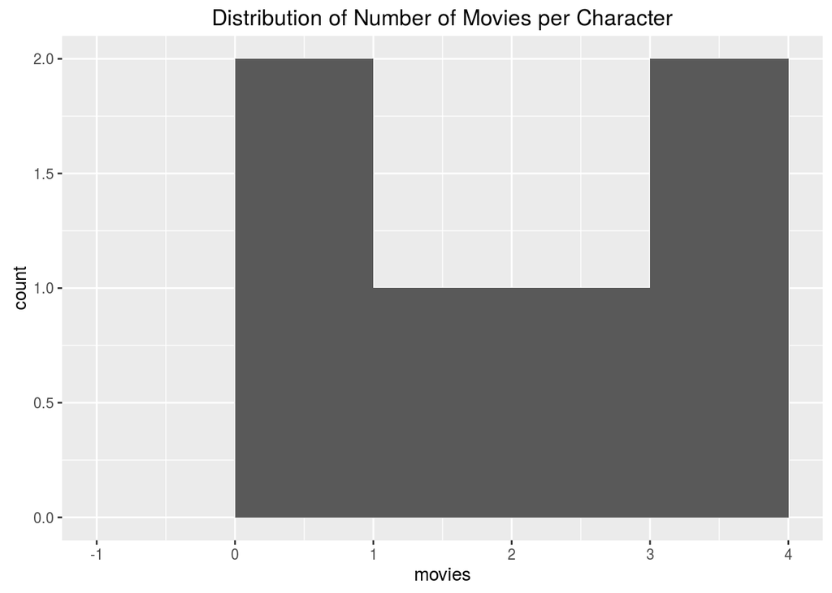

```r
ggplot(avengers, aes(x = movies)) +
    geom_histogram( binwidth = 1 ) +    # change the binwidth...
    ggtitle("Distribution of Number of Movies per Character")
```

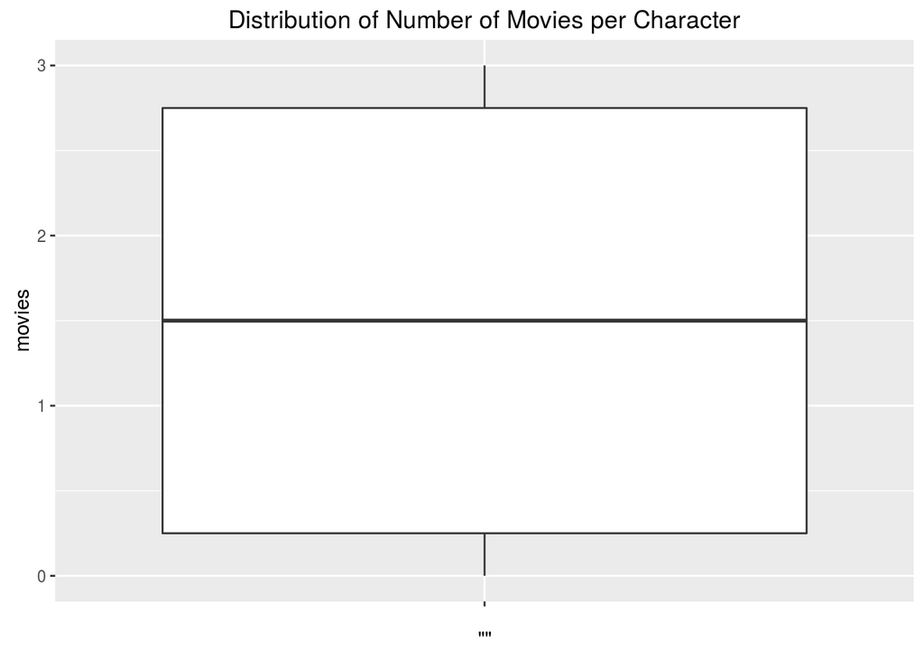

```r
ggplot(avengers, aes(x = "", y = movies)) +
    geom_boxplot() +
    ggtitle("Distribution of Number of Movies per Character")
```

#### Model

- Compute summary statistics

```r
nrow(avengers)
```

```
## [1] 6
```

```r
summary(avengers$movies)
```

```
##    Min. 1st Qu.  Median    Mean 3rd Qu.    Max.
##    0.00    0.25    1.50    1.50    2.75    3.00
```

```r
sd(avengers$movies)
```

```
## [1] 1.378405
```

#### Questions

- How many movies have been made?
- Average number of movies?
- Who has the most movies?

```r
sum(avengers$movies)
```

```
## [1] 9
```

```r
mean(avengers$movies)
```

```
## [1] 1.5
```

```r
avengers[ avengers$movies == max(avengers$movies), ]
```

```
##         character movies
## 1        Iron Man      3
## 4 Captain America      3
```

As usual, there is more than one way to get an answer. We could use the subset function instead of the single bracket

```r
subset(avengers, avengers$movies == max(avengers$movies)) # subset with function
```

```
##         character movies
## 1        Iron Man      3
## 4 Captain America      3
```

Or, we could sort the data frame in ascending order by the number of movies, then show the last 3 entries

```r
tail( avengers[ order(avengers$movies),], 3)
```

```
##         character movies
## 3            Thor      2
## 1        Iron Man      3
## 4 Captain America      3
```

#### Answers

- *How many movies have been made?* 9
- *Average number of movies?* 1.5
- *Who has the most movies?* It’s a tie: Iron Man, Captain America
- *Which character is most successful?* Hard to tell without more data.

#### Import data (movies)

Start another iteration.

This number of movies by itself is not conclusive. Lets get more information about the movies. Again, from Wikipedia: https://en.wikipedia.org/wiki/List_of_Marvel_Cinematic_Universe_films#Box_office_performance

```r
movies <- data.frame(title = c("Iron Man",
                               "The Incredible Hulk",
                               "Iron Man 2",
                               "Thor",
                               "Captain America: The First Avenger",
                               "Marvel's The Avengers",
                               "Iron Man 3",
                               "Thor: The Dark World",
                               "Captain America: The Winter Soldier",
                               "Guardians of the Galaxy",
                               "Avengers: Age of Ultron",
                               "Ant-Man",
                               "Captain America: Civil War"),

                     revenue = c("$585,174,222",
                                 "$263,427,551",
                                 "$623,933,331",
                                 "$449,326,618",
                                 "$370,569,774",
                                 "$1,519,557,910",
                                 "$1,215,439,994",
                                 "$644,602,516",
                                 "$714,421,503",
                                 "$773,312,399",
                                 "$1,405,413,868",
                                 "$519,445,163",
                                 "$1,152,745,930"),

                     released = c("May 2, 2008",
                                  "June 13, 2008",
                                  "May 7, 2010",
                                  "May 6, 2011",
                                  "July 22, 2011",
                                  "May 4, 2012",
                                  "May 3, 2013",
                                  "November 8, 2013",
                                  "April 4, 2014",
                                  "August 1, 2014",
                                  "May 1, 2015",
                                  "July 17, 2015",
                                  "May 6, 2016")
                     )

movies
```

```
##                                  title        revenue         released
## 1                             Iron Man   $585,174,222      May 2, 2008
## 2                  The Incredible Hulk   $263,427,551    June 13, 2008
## 3                           Iron Man 2   $623,933,331      May 7, 2010
## 4                                 Thor   $449,326,618      May 6, 2011
## 5   Captain America: The First Avenger   $370,569,774    July 22, 2011
## 6                Marvel's The Avengers $1,519,557,910      May 4, 2012
## 7                           Iron Man 3 $1,215,439,994      May 3, 2013
## 8                 Thor: The Dark World   $644,602,516 November 8, 2013
## 9  Captain America: The Winter Soldier   $714,421,503    April 4, 2014
## 10             Guardians of the Galaxy   $773,312,399   August 1, 2014
## 11             Avengers: Age of Ultron $1,405,413,868      May 1, 2015
## 12                             Ant-Man   $519,445,163    July 17, 2015
## 13          Captain America: Civil War $1,152,745,930      May 6, 2016
```

```r
str(movies)
```

```
## 'data.frame':    13 obs. of  3 variables:
##  $ title   : Factor w/ 13 levels "Ant-Man","Avengers: Age of Ultron",..: 7 11 8 12 4 10 9 13 5 6 ...
##  $ revenue : Factor w/ 13 levels "$1,152,745,930",..: 9 5 10 7 6 4 2 11 12 13 ...
##  $ released: Factor w/ 13 levels "April 4, 2014",..: 7 5 12 10 4 9 8 13 1 2 ...
```

#### Tidy (movies)

Looks pretty good.

#### Transform (movies)

Before we can plot anything or compute summary statistics

- Convert factors to characters (so we can manipulate the text)
- Convert revenues to numeric values, change units
- Capture the dates

```r
movies$title <- as.character( movies$title )
movies$revenue <- as.integer( gsub('[$,]', '', movies$revenue ) ) / 1000000
movies$released <- as.Date( as.character( movies$released ), format = "%B %d, %Y")
```

Print the data and view structure to see the effect

```r
print(movies)
```

```
##                                  title   revenue   released
## 1                             Iron Man  585.1742 2008-05-02
## 2                  The Incredible Hulk  263.4276 2008-06-13
## 3                           Iron Man 2  623.9333 2010-05-07
## 4                                 Thor  449.3266 2011-05-06
## 5   Captain America: The First Avenger  370.5698 2011-07-22
## 6                Marvel's The Avengers 1519.5579 2012-05-04
## 7                           Iron Man 3 1215.4400 2013-05-03
## 8                 Thor: The Dark World  644.6025 2013-11-08
## 9  Captain America: The Winter Soldier  714.4215 2014-04-04
## 10             Guardians of the Galaxy  773.3124 2014-08-01
## 11             Avengers: Age of Ultron 1405.4139 2015-05-01
## 12                             Ant-Man  519.4452 2015-07-17
## 13          Captain America: Civil War 1152.7459 2016-05-06
```

```r
str(movies)
```

```
## 'data.frame':    13 obs. of  3 variables:
##  $ title   : chr  "Iron Man" "The Incredible Hulk" "Iron Man 2" "Thor" ...
##  $ revenue : num  585 263 624 449 371 ...
##  $ released: Date, format: "2008-05-02" "2008-06-13" ...
```

#### Visualize (movies)

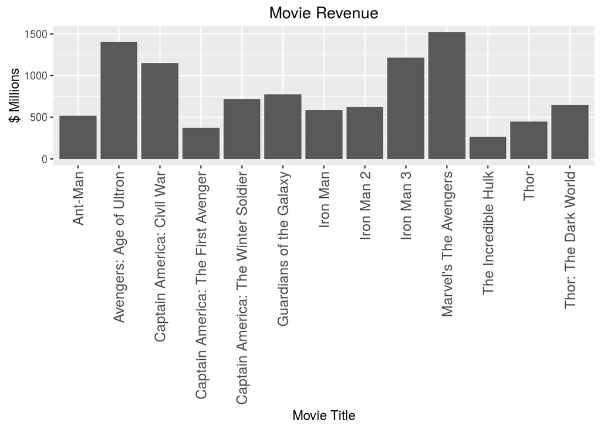

```r
# bar plot
ggplot(movies, aes(x = title, y = revenue)) +
    geom_bar(stat = "identity") +
    ggtitle("Movie Revenue") +
    xlab("Movie Title") + ylab("$ Millions") +
    theme(axis.text.x  = element_text(angle=90, vjust=0.5, hjust = 1, size=12))
```

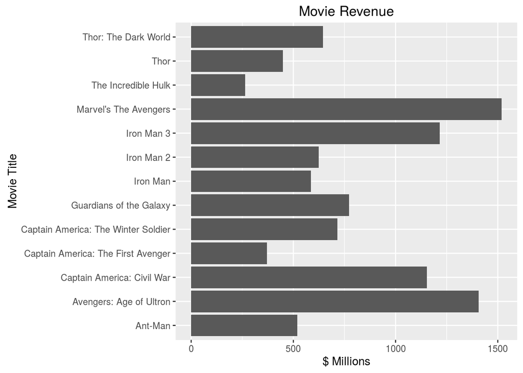

```r
# horizontal bar plot
ggplot(movies, aes(x = title, y = revenue)) +
    geom_bar(stat = "identity") +
    ggtitle("Movie Revenue") +
    xlab("Movie Title") + ylab("$ Millions") +
    coord_flip()
```

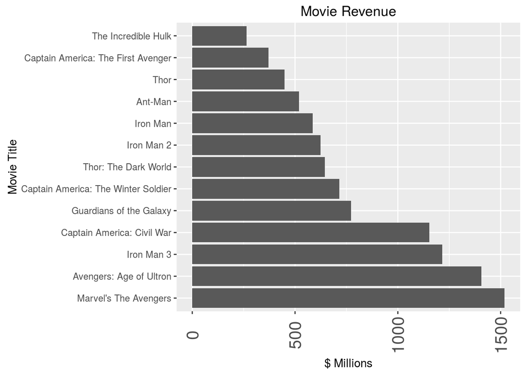

```r
# sorted horizontal bar plot
ggplot(movies, aes(x = reorder(title, -revenue), y = revenue)) +
    geom_bar(stat = "identity") +
    ggtitle("Movie Revenue") +
    xlab("Movie Title") + ylab("$ Millions") +
    theme(axis.text.x  = element_text(angle=90, vjust=0.5, size=16)) +
    coord_flip()
```

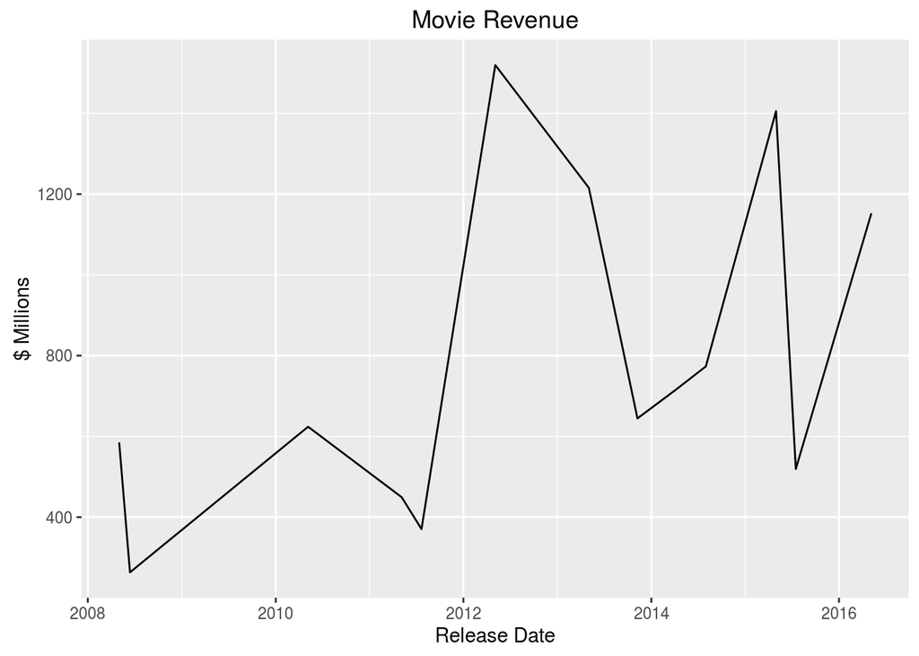

```r
# line plot
ggplot(movies, aes(x = released, y = revenue)) +
    geom_line() +
    ggtitle("Movie Revenue") +
    xlab("Release Date") + ylab("$ Millions")
```

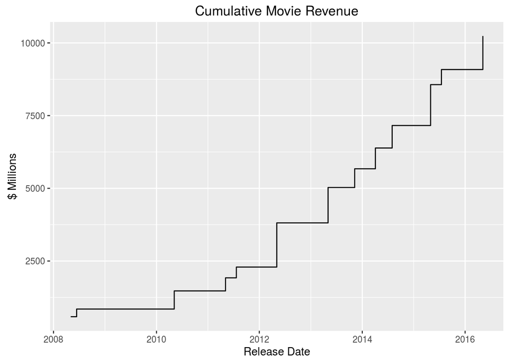

```r
# cumulative plot (step)
ggplot(movies, aes(x = released, y = cumsum(revenue))) +
    geom_step() +
    ggtitle("Cumulative Movie Revenue") +
    xlab("Release Date") + ylab("$ Millions")
```

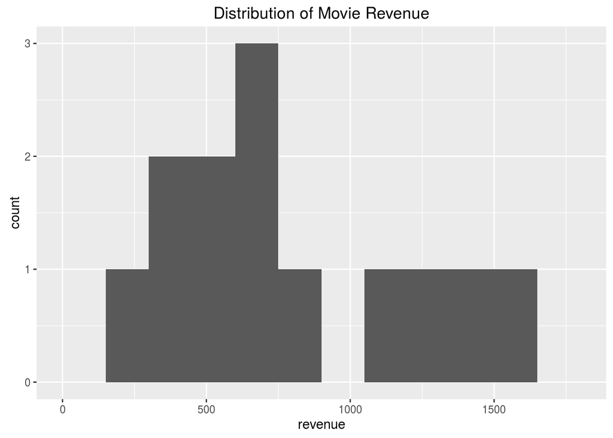

```r
# histogram
ggplot(movies, aes(x = revenue)) +
    geom_histogram(binwidth=150) +
    ggtitle("Distribution of Movie Revenue")
```

#### Model (movies)

```r
nrow(movies)
```

```
## [1] 13
```

```r
summary(movies$revenue)
```

```
##    Min. 1st Qu.  Median    Mean 3rd Qu.    Max.
##   263.4   519.4   644.6   787.5  1153.0  1520.0
```

```r
sd(movies$revenue)
```

```
## [1] 404.4144
```

#### Questions (movies)

- How many movies have been made? > nrow(movies)
- Average revenue? > round(mean(movie$revenue), digits=0)
- Which movie made the least? > movies[ movies$revenue == min(movies$revenue), “title”]
- Which avenger made the most money?

#### Transform – create a variable with coding

It’s possible to tell who the hero is from the title. Here we want to use a simple rule to make a new variable. If the title has the name of an avenger in it, then that avenger must be the main character. Reasonable?

Steps

- Define this rule in R
- Add a column for character to the movies data frame

Programming solution: Define a function to figure out the main character based on the title. Strategy

Given a set of titles and a set of hero names as input:

1. Search for hero name in every title
2. where there is a match, update x with the hero name
3. repeat for every hero name, updating x each time
4. if no match, x remains NA
5. Return x, a vector of with the (last) hero name found in each title

Iterate using for(), check conditions using ifelse(), and search for text using grepl()

```r
find_hero <- function(title, heroes) {
    x <- rep(NA, length(title))

    for (i in 1:length(heroes)) {
        x <- ifelse(grepl(heroes[i], title), heroes[i], x)
    }

    return(x)
}
```

Now, check if it works. The answer should be c(“Thor”, NA)

```r
find_hero(c("Thor Ragnorok", "The Amazing Spiderman"),
          c("Thor", "Superman", "Wonder Woman"))
```

```
## [1] "Thor" NA
```

Put it to work – create a new column of data in movies

```r
movies$character <- find_hero(movies$title, avengers$character)

movies
```

```
##                                  title   revenue   released
## 1                             Iron Man  585.1742 2008-05-02
## 2                  The Incredible Hulk  263.4276 2008-06-13
## 3                           Iron Man 2  623.9333 2010-05-07
## 4                                 Thor  449.3266 2011-05-06
## 5   Captain America: The First Avenger  370.5698 2011-07-22
## 6                Marvel's The Avengers 1519.5579 2012-05-04
## 7                           Iron Man 3 1215.4400 2013-05-03
## 8                 Thor: The Dark World  644.6025 2013-11-08
## 9  Captain America: The Winter Soldier  714.4215 2014-04-04
## 10             Guardians of the Galaxy  773.3124 2014-08-01
## 11             Avengers: Age of Ultron 1405.4139 2015-05-01
## 12                             Ant-Man  519.4452 2015-07-17
## 13          Captain America: Civil War 1152.7459 2016-05-06
##          character
## 1         Iron Man
## 2             Hulk
## 3         Iron Man
## 4             Thor
## 5  Captain America
## 6             <NA>
## 7         Iron Man
## 8             Thor
## 9  Captain America
## 10            <NA>
## 11            <NA>
## 12            <NA>
## 13 Captain America
```

```r
str(movies)
```

```
## 'data.frame':    13 obs. of  4 variables:
##  $ title    : chr  "Iron Man" "The Incredible Hulk" "Iron Man 2" "Thor" ...
##  $ revenue  : num  585 263 624 449 371 ...
##  $ released : Date, format: "2008-05-02" "2008-06-13" ...
##  $ character: chr  "Iron Man" "Hulk" "Iron Man" "Thor" ...
```

```r
movie_heroes <- c("Iron Man", "Hulk", "Iron Man", "Thor",
                  "Captain America", NA, "Iron Man", "Thor",
                  "Captain America", NA, NA, NA,
                  "Captain America")

# movie$character <- movie_heroes
```

One way or the other, we have a transformed movies data frame that includes both revenue and character information.

#### Transform – Aggregate with dplyr

- Compute the total revenue for each character – using what we have seen in previous lectures

```r
library(dplyr)
earnings <- movies %>%
                group_by(character) %>%
                summarise(revenue = sum(revenue)) %>%
                data.frame()

earnings
```

```
##         character   revenue
## 1 Captain America 2237.7372
## 2            Hulk  263.4276
## 3        Iron Man 2424.5475
## 4            Thor 1093.9291
## 5            <NA> 4217.7293
```

```r
str(earnings)
```

```
## 'data.frame':    5 obs. of  2 variables:
##  $ character: chr  "Captain America" "Hulk" "Iron Man" "Thor" ...
##  $ revenue  : num  2238 263 2425 1094 4218
```

### Time series Data

A single measure, or set of measures, observed at different points in time.

> “Most commonly, a *time series* is a sequence taken at successive equally spaced points in time. Thus it is a sequence of discrete-time data. Examples of time series are heights of ocean tides, counts of sunspots, and the daily closing value of the Dow Jones Industrial Average”

*- Source [Wikipedia, 2016-09-15](https://en.wikipedia.org/wiki/Time_series)*

### Time Series Example 1

For our first example in this lecture we will use time series estimated and published quarterly by the Federal Reserve Board.

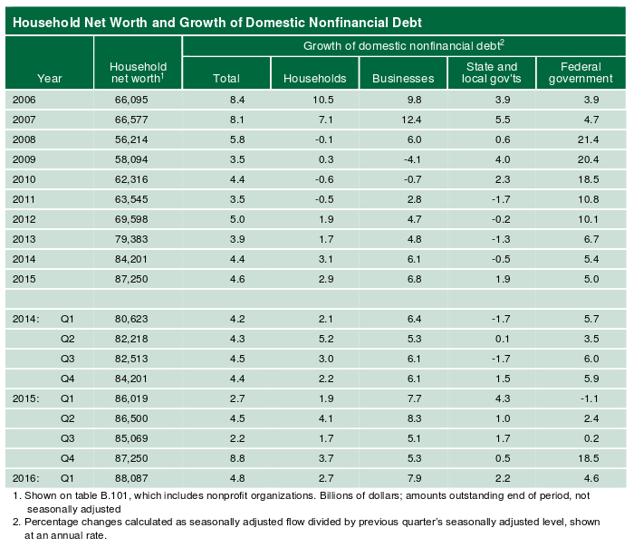

This table shows 6 time series, arranged in columns. Source: [Financial Accounts of the United States, June 2016](http://www.federalreserve.gov/releases/z1/current/).

Documentation is available online (http://www.federalreserve.gov/apps/fof/), search by series name

```r
fof_mnemonics <- c("FL152090005" = "Household Net Worth",
                   "FG384104005" = "Growth of domestic nonfinancial debt; Total",
                   "FG154104005" = "Growth of domestic nonfinancial debt; Households",
                   "FG144104005" = "Growth of domestic nonfinancial debt; Businesses",
                   "FG214104005" = "Growth of domestic nonfinancial debt; State and local govt's",
                   "FG314104005" = "Growth of domestic nonfinancial debt; Federal government")
```

### Step 1 - Import

Get raw data (from the source)

The table above is available for download in csv format

1. Download the zip file, extract the file we need
2. Read the raw data into R
3. View data
   1. in RStudio Environment
   2. using R commands
4. Describe findings

*In Class Exercise 4*

Create a program using the following code template. Run it and inspect the results.

```r
# Exploring Data: US Household Net Worth and Debt Growth
#
# This script downloads public data from the Federal Reserve Board and
# uses it to demonstrate how to carry out simple exploratory analysis
# tasks in R.

# Load Packages
# to start we will use only base R functions

# Download the zip file
download.file(url = "http://www.federalreserve.gov/releases/z1/z1-csv-20160617.zip",
              destfile = "data/z1-csv-20160617.zip")

# Extract the file we need
unzip("data/z1-csv-20160617.zip", files = c("csv/summary.csv"), exdir = "data", junkpaths = TRUE)

# Read the raw data into R
df <- read.csv("data/summary.csv")

# View the data frame
head(df)
str(df)
```

Here’s what you should get after downloading the data

```r
# Read the raw data into R
df <- read.csv("data/summary.csv")

# View the data frame
head(df)
```

```
##   Date Household.Net.Worth Total
## 1 2006               66095   8.4
## 2 2007               66577   8.1
## 3 2008               56214   5.8
## 4 2009               58094   3.5
## 5 2010               62316   4.4
## 6 2011               63545   3.5
##   Growth.of.domestic.nonfinancial.debt..Households
## 1                                             10.5
## 2                                              7.1
## 3                                             -0.1
## 4                                              0.3
## 5                                             -0.6
## 6                                             -0.5
##   Growth.of.domestic.nonfinancial.debt..Businesses
```

[output cut: 20 more lines]

```r
str(df)
```

```
## 'data.frame':    19 obs. of  7 variables:
##  $ Date                                                        : Factor w/ 19 levels "2006","2007",..: 1 2 3 4 5 6 7 8 9 14 ...
##  $ Household.Net.Worth                                         : int  66095 66577 56214 58094 62316 63545 69598 79383 84201 87250 ...
##  $ Total                                                       : num  8.4 8.1 5.8 3.5 4.4 3.5 5 3.9 4.4 4.6 ...
##  $ Growth.of.domestic.nonfinancial.debt..Households            : num  10.5 7.1 -0.1 0.3 -0.6 -0.5 1.9 1.7 3.1 2.9 ...
##  $ Growth.of.domestic.nonfinancial.debt..Businesses            : num  9.8 12.4 6 -4.1 -0.7 2.8 4.7 4.8 6.1 6.8 ...
##  $ Growth.of.domestic.nonfinancial.debt..State.and.local.govts.: num  3.9 5.5 0.6 4 2.3 -1.7 -0.2 -1.3 -0.5 1.9 ...
##  $ Growth.of.domestic.nonfinancial.debt..Federal.government    : num  3.9 4.7 21.4 20.4 18.5 10.8 10.1 6.7 5.4 5 ...
```

- *What can we say about the data?*
  - Variable names
  - Number of observations
  - Data types
  - Data values

### Step 2 - Tidy

Problems

1. Default data types don’t make sense
   - categorical date?
2. Long variable names
3. Too many numbers to look at

Fixes

1. Set read.csv() options, and transform data
2. Rename variables
3. Summarize

*In Class Exercise 5*

Expand on the previous program. Run it and inspect the results.

```r
# Load Packages


# Data source
source_url <- "http://www.federalreserve.gov/releases/z1/z1-csv-20160617.zip"


# Download the zip file (if we need it)
if ( !file.exists("data/z1-csv-20160617.zip") & !file.exists("data/summary.csv") ) {
    download.file(url = source_url, destfile = "data/z1-csv-20160617.zip")
}

# Extract the file (if we need it)
if ( !file.exists("data/summary.csv") ) {
    unzip("data/z1-csv-20160617.zip", files = c("csv/summary.csv"), exdir = "data", junkpaths = TRUE)
}

# Read the raw data into R
df <- read.csv("data/summary.csv", stringsAsFactors = FALSE, header = FALSE, skip = 1)

# Set variable names
names(df) <- c("date_label",
               "household_net_worth",
               "total_debt_growth",
               "household_debt_growth",
               "business_debt_growth",
               "state_local_debt_growth",
               "federal_debt_growth")

# identify annual observations
df$annual <- ! grepl(':Q', df$date_label)

# separate year and quarter information
df$year   <- as.integer(gsub(':Q.*$', '', df$date_label))
df$q      <- ifelse(df$annual, NA, as.integer(gsub('.*:Q', '', df$date_label)))

# use fractions to represent quarters
# Q1 = 0.00, Q2 = 0.25, Q3 = 0.50, Q4 = 0.75
df$quarter <- df$year + ((df$q-1) / 4)

# View the data
head(df)
```

```
##   date_label household_net_worth total_debt_growth household_debt_growth
## 1       2006               66095               8.4                  10.5
## 2       2007               66577               8.1                   7.1
## 3       2008               56214               5.8                  -0.1
## 4       2009               58094               3.5                   0.3
## 5       2010               62316               4.4                  -0.6
## 6       2011               63545               3.5                  -0.5
##   business_debt_growth state_local_debt_growth federal_debt_growth annual
## 1                  9.8                     3.9                 3.9   TRUE
## 2                 12.4                     5.5                 4.7   TRUE
## 3                  6.0                     0.6                21.4   TRUE
## 4                 -4.1                     4.0                20.4   TRUE
## 5                 -0.7                     2.3                18.5   TRUE
## 6                  2.8                    -1.7                10.8   TRUE
##   year  q quarter
## 1 2006 NA      NA
## 2 2007 NA      NA
## 3 2008 NA      NA
## 4 2009 NA      NA
## 5 2010 NA      NA
## 6 2011 NA      NA
```

```r
str(df)
```

```
## 'data.frame':    19 obs. of  11 variables:
##  $ date_label             : chr  "2006" "2007" "2008" "2009" ...
##  $ household_net_worth    : int  66095 66577 56214 58094 62316 63545 69598 79383 84201 87250 ...
##  $ total_debt_growth      : num  8.4 8.1 5.8 3.5 4.4 3.5 5 3.9 4.4 4.6 ...
##  $ household_debt_growth  : num  10.5 7.1 -0.1 0.3 -0.6 -0.5 1.9 1.7 3.1 2.9 ...
##  $ business_debt_growth   : num  9.8 12.4 6 -4.1 -0.7 2.8 4.7 4.8 6.1 6.8 ...
##  $ state_local_debt_growth: num  3.9 5.5 0.6 4 2.3 -1.7 -0.2 -1.3 -0.5 1.9 ...
##  $ federal_debt_growth    : num  3.9 4.7 21.4 20.4 18.5 10.8 10.1 6.7 5.4 5 ...
##  $ annual                 : logi  TRUE TRUE TRUE TRUE TRUE TRUE ...
##  $ year                   : int  2006 2007 2008 2009 2010 2011 2012 2013 2014 2015 ...
##  $ q                      : int  NA NA NA NA NA NA NA NA NA NA ...
##  $ quarter                : num  NA NA NA NA NA NA NA NA NA NA ...
```

```r
# Quick summary stats
summary(df)
```

```
##   date_label        household_net_worth total_debt_growth
##  Length:19          Min.   :56214       Min.   :2.200
##  Class :character   1st Qu.:66336       1st Qu.:4.050
##  Mode  :character   Median :82218       Median :4.400
##                     Mean   :76619       Mean   :4.842
##                     3rd Qu.:85544       3rd Qu.:4.900
##                     Max.   :88087       Max.   :8.800
##
##  household_debt_growth business_debt_growth state_local_debt_growth
##  Min.   :-0.600        Min.   :-4.100       Min.   :-1.700
##  1st Qu.: 1.700        1st Qu.: 4.950       1st Qu.:-0.350
##  Median : 2.200        Median : 6.100       Median : 1.000
##  Mean   : 2.784        Mean   : 5.621       Mean   : 1.179
##  3rd Qu.: 3.400        3rd Qu.: 7.250       3rd Qu.: 2.250
##  Max.   :10.500        Max.   :12.400       Max.   : 5.500
##
##  federal_debt_growth   annual             year            q
##  Min.   :-1.100      Mode :logical   Min.   :2006   Min.   :1.000
##  1st Qu.: 4.250      FALSE:9         1st Qu.:2010   1st Qu.:1.000
##  Median : 5.700      TRUE :10        Median :2014   Median :2.000
##  Mean   : 8.032      NA's :0         Mean   :2012   Mean   :2.333
##  3rd Qu.:10.450                      3rd Qu.:2015   3rd Qu.:3.000
##  Max.   :21.400                      Max.   :2016   Max.   :4.000
##                                                     NA's   :10
##     quarter
##  Min.   :2014
##  1st Qu.:2014
##  Median :2015
##  Mean   :2015
##  3rd Qu.:2016
##  Max.   :2016
##  NA's   :10
```